### Sheffield Assignment: Predictive modelling using crowdsourced text data from FixMyStreet reports

#### Introduction:

In this report, I look at reports made on FixMyStreet (https://www.fixmystreet.com). FixMyStreet is “a UK based issue reporting service allowing citizens to report problems in their area through a single portal that sends the report to the appropriate local authority” (Parsons, et al. 2019).

The data contains information on the type of issue, a textual description of the issue provided by the user, the date, time, and geographical location of the report, and the means through which the report was made (iPhone, Android, or online website).

Most studies on crowdsourced reports, sometimes called ‘311 data’ after the American 311 services (for example:https://portal.311.nyc.gov), focuses on the geographical and temporal aspects of the reports, and there is little analysis on the text component which may be rich with insights.

In this report, I will take a predictive modelling approach to estimate whether or not a report is about potholes based on the text provided.

I will begin by performing some exploratory analysis and then move on to pre-processing the data.

I will then fit a logistic regression model using least absolute shrinkage and selection operator (lasso) using the glmnet package. I will use 10 fold cross-validation to optimise two hyper-parameters: the amount of regularization applied, and the number of tokens retained.

Finally, I will assess the performance of the model, visualize the results of the model and of the hyper-parameter optimization process, and reflect upon limitations of the model and potential further optimisations.

#### Exploratory analysis:

In this section, I will explore some of the variables in the data-set, specifically the “description” variable which contains text submitted by users providing information on the problem they are reporting, the “category” variable which contains a label describing the type of problem the user is reporting, and the “date” variable which contains the date the problem was reported.

First, we can explore the text variable by looking at a random sample of reports:

```
##  [1] "Please can potholes be repaired on hornby road asap. thanks"
##  [2] "Criminal damage (graffiti) to side of building located in university car park. Same criminal has defaced the side of the Western Bank flyover adjacent to the Hicks building."
##  [3] "This ongoing problem makes the road and surroundings look terrible. Please can we have this mess removed and cameras installed to prevent repeat behaviour."
##  [4] "Graffiti on wall near fifteen Queen Street."
##  [5] "Very deep pothole centre of road to accompany the one you haven&#39;t bothered to fix that I reported weeks ago."
##  [6] "Dumped on corner of Charles st adj Hightown Rd next to street name sign"
##  [7] "The potholes have been here for over a year, they are getting worse and you can see more appearing. Not only is it dangerous for cars as it is in the bend of the road. It can and will cause damage to vehicles, cyclists are also having to avoid the potholes. Being so close to the house the c…
##  [8] "I have no path outside of my house and find it almost impossible at times to cross the road with my two young children as cars fly by so fast! There&#39;s a school also so it is a well used road by many young children not just mine. There needs to be a continuation of the speed bumps furthe…
##  [9] "Post to stop cars running over grass verge has been uprooted and is lying on mud. Needs replanting more securely as it is the second time."
## [10] "The road has been deteriorating for years with no maintenance"
```

We can see that the descriptions can provide quite a rich description of the problem being reported.

Our target variable is the category of the report, we can look at the most common reports by plotting a bar chart of all category types which have more than 1000 reports.

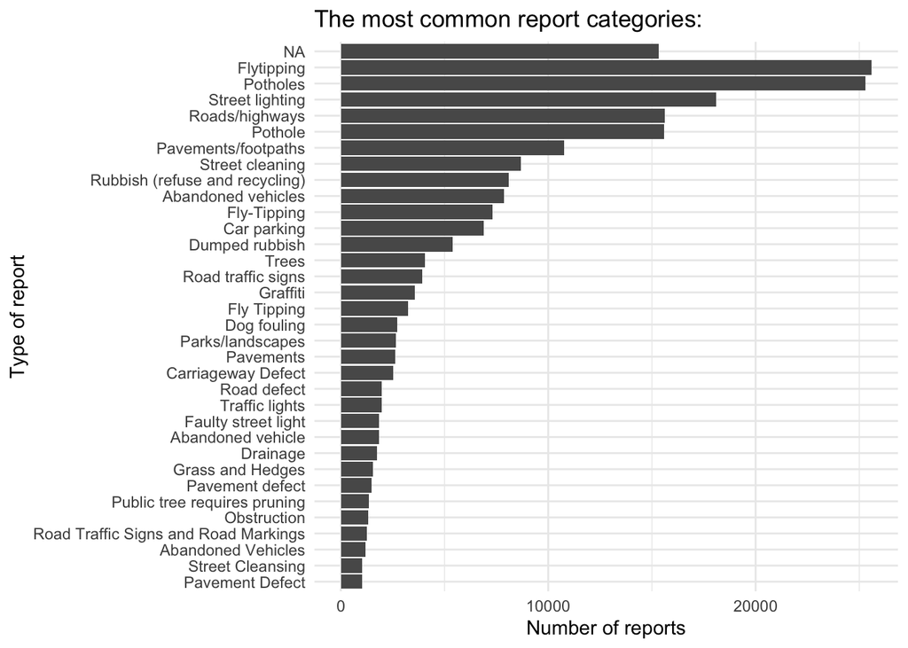

Unfortunately, Fix My Street allows its users to write in their own categories.

In total there are 209 different categories. Some of these categories are simply different spellings of the same issue (for example Potholes and Pothole, or Flytipping, Fly-Tipping, and Fly Tipping) and should probably be combined.

After combining the above categories we end up with the following category distribution:

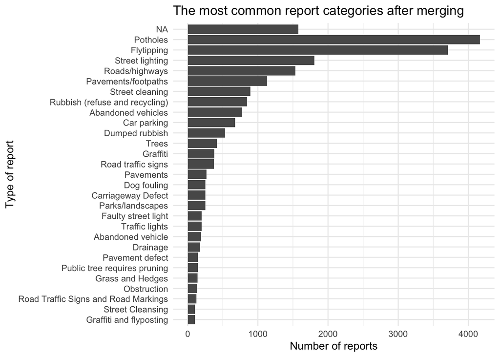

There are two issues raised by these graphs. First, there are a high number of NA’s, some of which may be potholes. Secondly, tsome categories seem like they could be referring to, or at least include reports referring to, potholes such as “Carriageway Defect”, “Road defect”, “Highways”, and “Roads/Highways”.

A council using the FixMyStreet app might want a reliable way of seeing how many are potholes have been reported. And since the “category” variable is not reliable, another approach might be to use a supervised learning approach on the “description” variable to create a model which can parse all the submissions and quickly determine which are referring to potholes.

Another variable which may improve the fit of such a model is the date variable. We can try plotting the three most commonly reported categories over time to see if there are any obvious temporal trends:

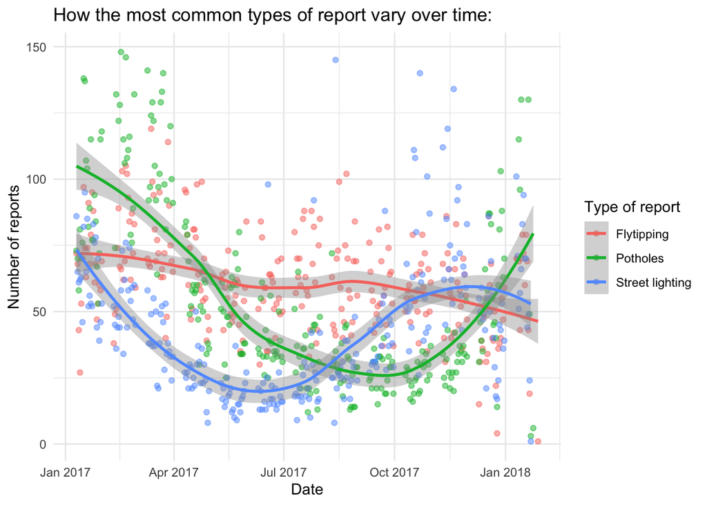

There are a number of interesting things happening here. First, reports of flytipping see to be declining over time.

Secondly, street lighting seems to experience some seasonal variation, with reports peaking in winter and being at their lowest in summer. A likely explanation for this is that faulty street lighting is more of an issue in winter when days are shorter, an explanation which seems supported by reports being at their lowest levels towards the end of June, where the summer solstice occurs.

Pothole reports seem to follow a similar pattern, though the curves appear “out of sync”.

In this section, I have graphically explored some of our variables of interest. In the next section, I will start pre-processing the data to fit a classification model.

#### Pre-processing:

In this section, I start pre-processing my data. This is done using the Tidymodels framework (Khun, et al. 2020), as well as two extensions: the themis package for upsampling (Hvitfeldt, 2020a), and the textrecipes package (Hvitfeldt, 2020b) for text processing functions.

First I re-coded the “Potholes” category as “Pothole” for the reasons mentioned above. I then created a binary outcome for our target variable by recoding all other categories as “Other”.

After recoding the distribution of the category variable looked like this:

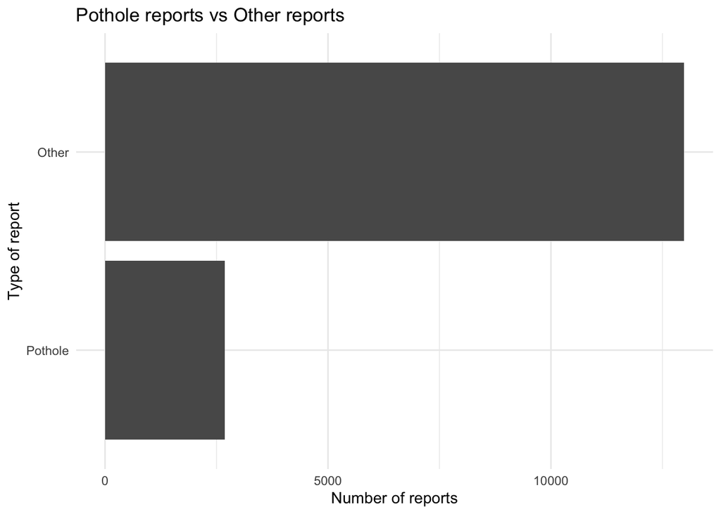

The second pre-processing task was to split the data into test and training data-sets.

Using stratified sampling to preserve an equal amount of “Pothole” and “Other” reports in each data-set, I assigned three-quarters of the data to the training data-set, with the last quarter being held out for testing.

I then up-sampled the number of “Pothole reports” so it matched the number of “Other” reports using the themis package. Critically, I only did this on the training data.

The next pre-processing step was to process the text data into a form that could be easily used by a machine learning algorithm.

First I turned the entries into tokenlist objects: a “thin wrapper around a list of character vectors, with a few attributes” (Hvitfeldt, 2020c). This is the preferred format for text data in the Tidymodels packages.

I then removed stopwords, and created n-grams of length one and two. I then removed any n_grams which appeared less than 5 times in the data as these were too infrequent to learn from reliably (and are often just typos). I also specified that n_grams that appeared more than a certain amount of times be removed. However as good values for this can vary a lot depending on the text used, I did not specify the maximum amount, instead leaving this value as a hyper-parameter to be optimised when fitting the model.

Finally, I calculated the term frequency-inverse document frequency for each token.

In this section I have pre-processed the data for our models, I have split the data into test and training sets, upsampled the “Pothole” category, created dummies for month and day of the week, and processed the text data in a number of ways. In the next section I will specify and fit the model.

#### Modelling:

In this section, I describe the steps taken to specify and fit the model.

The first step was to specify which model to use, I opted for a logistic regression model using least absolute shrinkage and selection operator (or lasso) from the glmnet package (Hastie, et al. 2010) as it is known to perform well on text classification tasks (Silge & Hvitfeldt, 2020a). The amount of regularization is set as one of the parameters to be optimized.

I then created a parameter grid with many possible combinations of values to be tested for our hyper-parameters.

The hyper-parameters were optimized using k-fold cross-validation with ten folds. As with our test-train split above, the cross validation folds were created using stratified sampling which made sure the proportion of “Pothole” vs “Other” reports was similar in each fold.

#### Results:

In this section, I will look at the results from my model. I will look at the best performing models, visualize some of the modelling process, and visualize model performance.

These are the values of the top five best performing models, ranked by area under the receiver operator curve (roc_auc), a mesure of how well a classification model has performed:

[output not shown]

We can also visualize how the results vary according to which hyper-parameters are used:

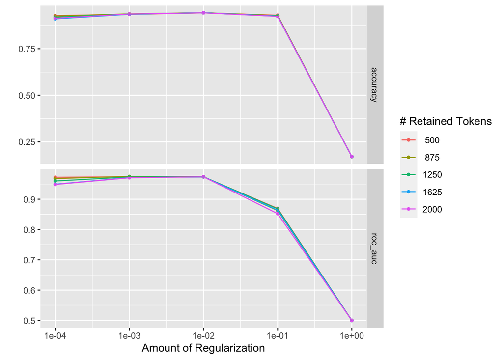

As we can see, the most important hyper-parameter is the amount of regularization applied, the number of tokens retained only has a noticeable impact when the amount of regularization is low.

We can also create a receiver operator curve for the best model, with each fold from the cross validation step shown in a different colour:

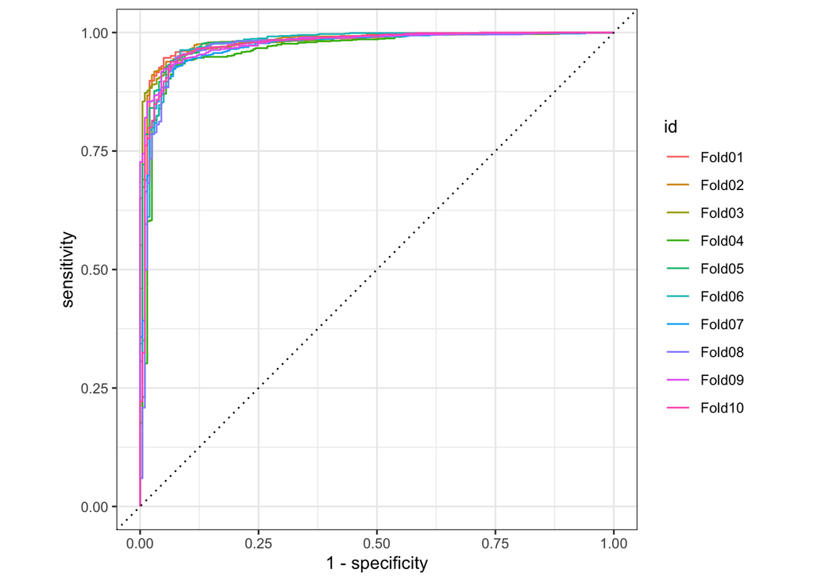

This seems like a very promising result. However all the calculations so far have been using our training data and so we can not rule out over-fitting.

We can apply our best performing model to our test data and see if it still performs as well.

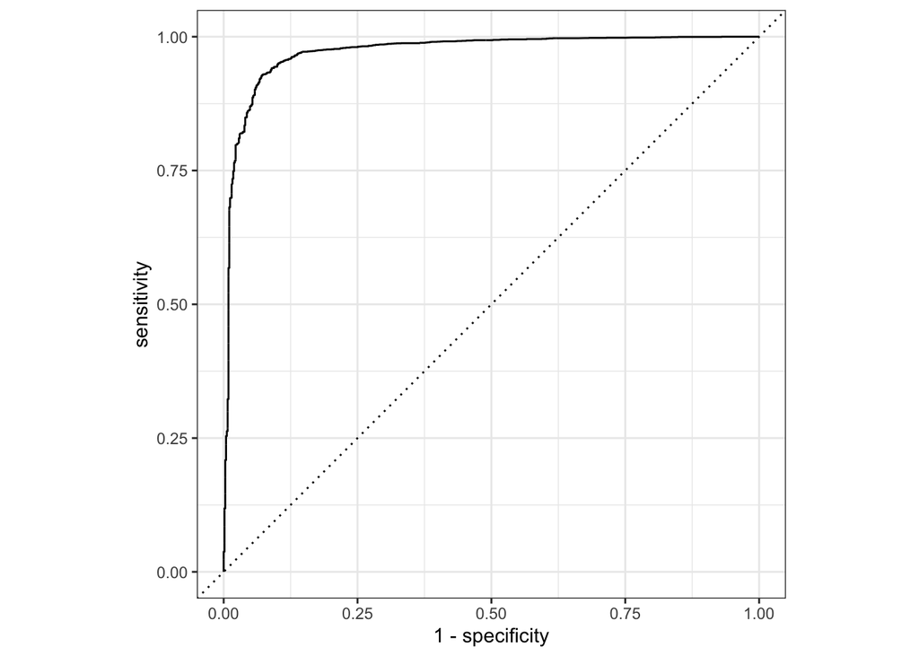

Luckily, our model does not appear to have significantly over-fit! However, a necessary caveat is that FixMyStreet data has a geographical component which I have not considered here. Due to spatial auto-correlation, cross-validated measures on geographical data can be over-optimistic unless a spatial cross-validation approach is used (Lovelace, et al. 2020).

We can also visualize aspects of our model other than performance. For example, we can visualize which variables were the most important in swaying our model to predict each of our outcomes using the vip package (Greenwell et al, 2020). These are the top 20 most important n_grams for each outcome:

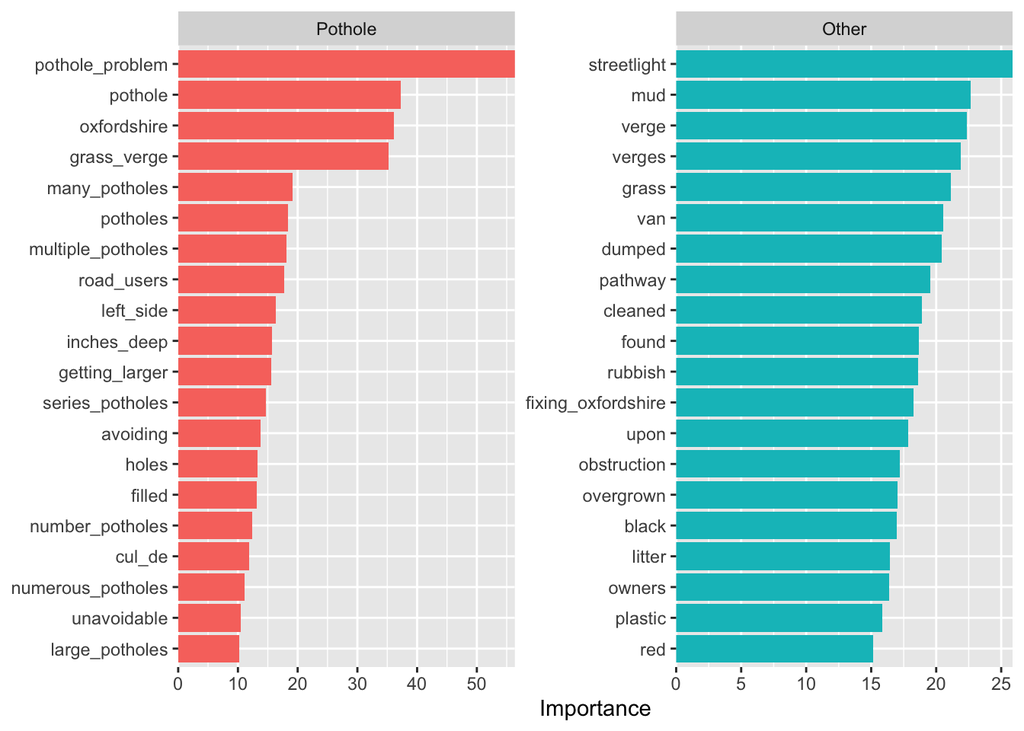

Another way of visualizing model output currently being developed by Emil Hvitfeldt and Julia Silge (Hvitfeldt & Silge, 2020b) is to look at some examples of our text inputs and colour words depending of which way they pushed the classification model, and how much they influenced the decision.

For these first two reports, words that pushed the model towards the “Pothole” outcome are shown in blue whilst words which suggested the “Other” outcome are shown in green. The deeper the colour, the more influential the word was in the classification outcome.

**First pothole report:**

there a lot of *potholes* *along* the *curb* furtest from the *shops* *house* *side* from the *pedestrian* *crossing* for about *12* meters you *can* *39* *t* *avoid* them most of the *time* *due* to *traffic* *parked* *outside* *shops* and *lorries* *etc* being so *big*

**Second report:**

not so *much* a *pothole* as a crater *approx* *1* *39* *x* *2* *39* *across* and *5* *quot* *deep* and *growing* by the *week* there are *numerous* other *potholes* but the crater is beyond belief *especially* as it is int he *middle* of the carpark *quot* *road* *quot* and not *just* in a *space* or off to the *side*

This is the same thing, but for two non-pothole related reports (this time green suggests “Pothole”, and blue suggests “Other”).

**First report:**

have *reported* this *previously* unfortunately ladbrokes has a *regular* *set* of drunks who routinely *drop* their *litter* *behind* this telephone *junction* *box* and all *along* the planter *next* to it have *reported* to lambeth *council* that i have *seen* rats emerging from this *location* and *others* in the *local* *area* the *street* cleaner does not *clean* *behind* this *box* on a *regular* *basis* and this *needs* to be addressed the *police* ladbrokes and lambeth *council* have *little* interest in dealing with the drunks bu i pay *council* taxt and expect the *street* *cleaning* to be *done* *properly* *it’s* *clearly* *becoming* a *hazard* if rats are out in the daylight and *rubbish* remains in *place* for *weeks* if not *months* at a *time*

**Second report:**

*someone* has *abandoned* a bicycle and *left* it on the *pavement* against the *wall* of our *front* *garden* it doesn *39* *t* *look* stolen as it is in *really* *poor* *condition* and the *wheels* *don* *39* *t* *turn* *properly* we *can* *also* *see* that a brake cable is *missing* so it *looks* *like* it *39* *s* been in this *condition* for sometime it has been there for *two* *days*

#### Conclusion:

In this report, I have explored a classification issue with data from FixMyStreet. Following some exploratory data analysis, I have outlined a problem in the way FixMyStreet data is categorized. I have shown that a supervised learning approach on the text data provided can help councils address this problem accurately and robustly.

#### Recommendations:

Councils should consider using a supervised learning approach when looking at data from FixMyStreet to obtain accurate, real-time, knowledge of pothole reports.

Further work should consider the spatial aspect of this data, which may increase performance on new data, as well as variables such as reporting mode.

#### Bibliography:

Greenwell, Brandon; Brad Boehmke and Bernie Gray (2020). vip: Variable Importance Plots. R package version 0.2.2. Available: https://CRAN.R-project.org/package=vip

Hastie, Trevor; Jerome Friedman, Robert Tibshirani (2010).*‘Regularization Paths for Generalized Linear Models viaCoordinate Descent.’* Journal of Statistical Software, 33(1),pages 1-22. Available: http://www.jstatsoft.org/v33/i01/.

Hvitfeldt, Emil. (2020a). themis: Extra Recipes Steps for Dealing with Unbalanced Data. R package version 0.1.1. Available: https://CRAN.R-project.org/package=themis

Hvitfeldt, Emil. (2020b). textrecipes: Extra ‘Recipes’ for Text Processing. R package version 0.3.0. Available: https://CRAN.R-project.org/package=textrecipes

Hvitfeldt, Emil. (2020b) ‘Create tokenlist object’ Available: https://textrecipes.tidymodels.org/reference/tokenlist.html

Kuhn et al., (2020). Tidymodels: a collection of packages for modeling and machine learning using tidyverse principles. Available: https://www.tidymodels.org

Lovelace, Robin, Jakub Nowosad, and Jannes Muenchow.(2019) Geocomputation with R. CRC Press. Available: https://geocompr.robinlovelace.net/spatial-cv.html

Parsons, Alex; Peter Matthews, Elvis Nyanzu, Alasdair Rae (Forthcoming). Dog Poo and Potholes: Patterns in citizen-reporting of local environmental quality and place-keeping

Silge, Julia and Emil Hvitfeldt (2020a).Supervised Machine Learning for Text Analysis in R. Available online: https://smltar.com

Silge, Julia and Emil Hvitfeldt (2020b) ‘Predictive modeling with text using tidy data principles’. Available: https://github.com/EmilHvitfeldt/useR2020-text-modeling-tutorial

#### Wordcount: 2201 words

#### Appendix:

This report was created in RMarkdown, the code is available here: https://github.com/NathanKhadaroo/Sheffield_Task/blob/master/Assignment.Rmd